# Film festival database 3rd dump impressions

# Country of origin, without duplicate removal

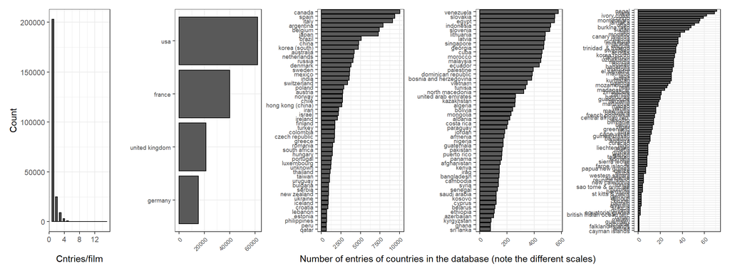

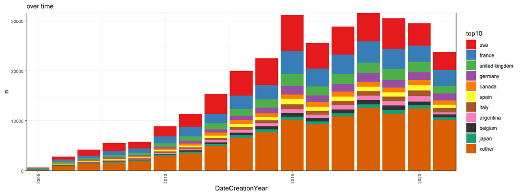

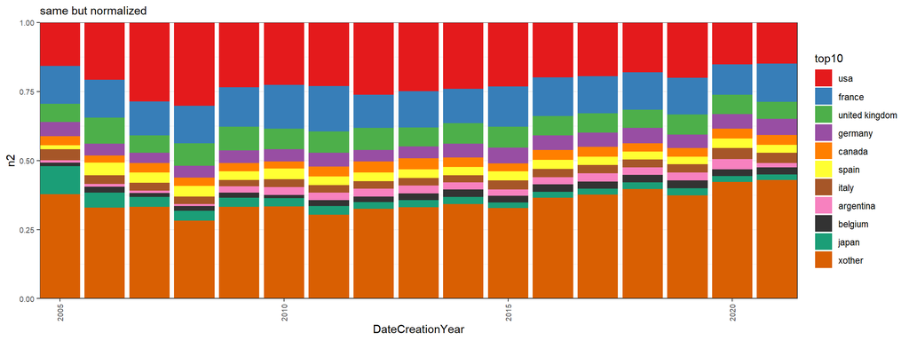

# What type of entity enters a film for sale

dbo.idxFilmRole table What type of entity enters a film for sale: connect to Film through refFilm column, entity type info from lstRole column. Categories are listed below. These come from the dbo.Menu table, column Libelle: 26001: Sales 26002: Distributor 26003: Producer 26004: Financier 26005: Festival 26006: Promotion 26007: Buyers’ Rep 26008: Consultant 26009: Broadcaster

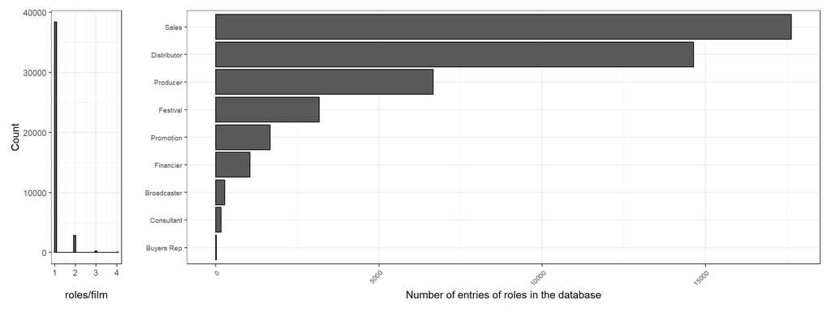

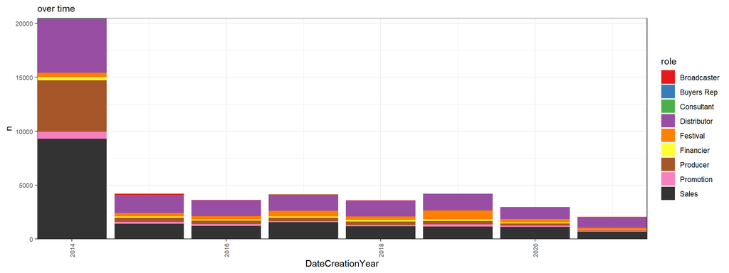

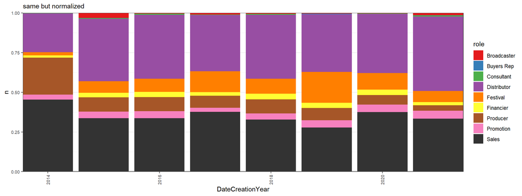

# What type of entity enters a film for sale, no duplicate removal

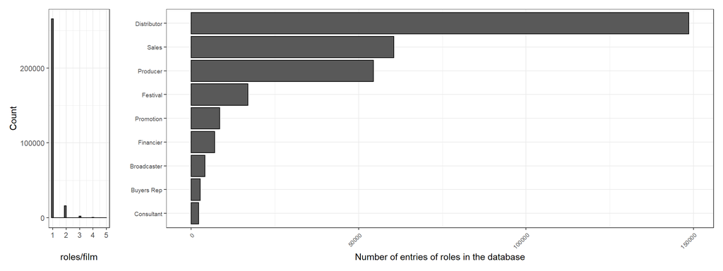

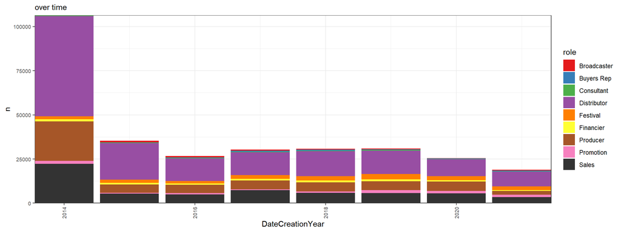

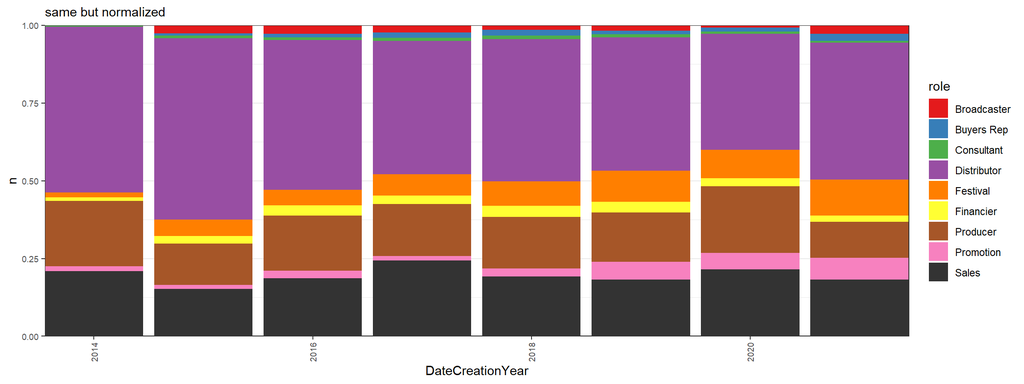

# What rights are for sale

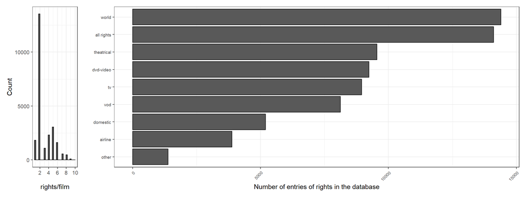

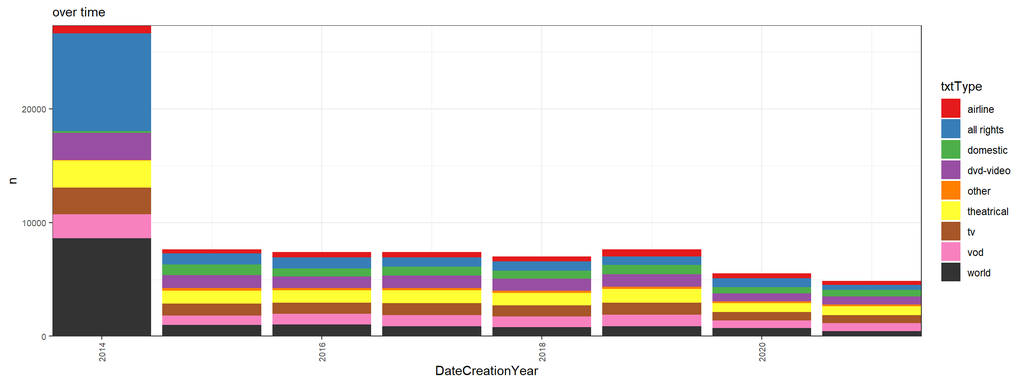

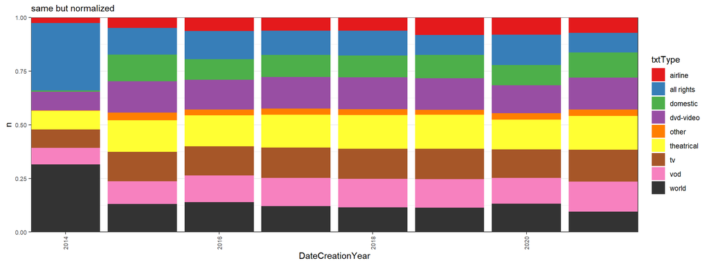

# What rights are for sale, no duplicate removal

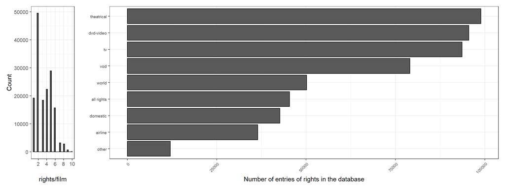

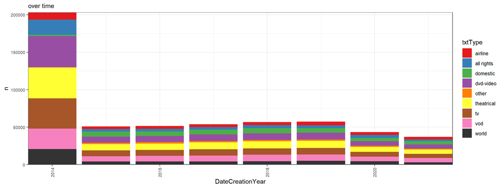

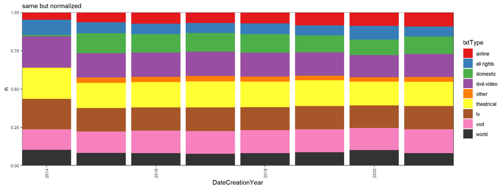

# Director gender

since this is international names, gender detection is not trivial. could probably make it work with not much effor for angloamerican names using existing resources.